# AI_Analysis

Aarul

2025-11-27

# Final Project Report: AI’s impact on the Job Market

## Collaborators: Aarul Motiani, Eshaan Garg, Wayne Zhao, Finn Caughie

================================================================================================================================================================ ## AARUL’S RESEARCH QUESTION: How has demand for AI-related roles grown over the past 5 years?

## Loading libraries and datasets

```r
library(tidyverse)
```

```r
library(ggplot2)
library(lubridate)

## Aarul's computer loaded datasets
job_postings <- read_delim("/Users/Aarul/UW/INFO 201/Final Project/INFO201_Final_Project/AI_Job_Posting_Trends.csv")
salary_data <- read_delim("/Users/Aarul/UW/INFO 201/Final Project/INFO201_Final_Project/data_science_salaries.csv")
```

## Data exploration for Aarul’s datasets

```r
head(job_postings)
```

```
## # A tibble: 6 × 18
##   job_id job_title   salary_usd salary_currency experience_level employment_type
##   <chr>  <chr>            <dbl> <chr>           <chr>            <chr>
## 1 XYZ001 AI Softwar…      76857 EUR             Executive        Contract
## 2 XYZ002 AI Archite…      68860 GBP             Entry_Level      Freelancer
## 3 XYZ003 AI Archite…     120112 EUR             Mid              Part Time
## 4 XYZ004 Principal …     112812 EUR             Entry_Level      Full Time
## 5 XYZ005 AI Researc…      63245 USD             Entry_Level      Part Time
## 6 XYZ006 AI Softwar…     153372 USD             Entry_Level      Contract
## # ℹ 12 more variables: company_location <chr>, company_size <chr>,
## #   employee_residence <chr>, remote_ratio <dbl>, required_skills <chr>,
## #   education_required <chr>, years_experience <dbl>, industry <chr>,
## #   posting_date <chr>, benefits_score <dbl>, company_name <chr>,
## #   remote_category <chr>
```

```r
names(job_postings)
```

```
##  [1] "job_id"             "job_title"          "salary_usd"
##  [4] "salary_currency"    "experience_level"   "employment_type"
##  [7] "company_location"   "company_size"       "employee_residence"
## [10] "remote_ratio"       "required_skills"    "education_required"
## [13] "years_experience"   "industry"           "posting_date"
## [16] "benefits_score"     "company_name"       "remote_category"
```

```r
nrow(job_postings)
```

```
## [1] 50000
```

```r
ncol(job_postings)
```

```
## [1] 18
```

```r
head(salary_data)
```

```
## # A tibble: 6 × 11
##   job_title      experience_level employment_type work_models work_year
##   <chr>          <chr>            <chr>           <chr>           <dbl>
## 1 Data Engineer  Mid-level        Full-time       Remote           2024
## 2 Data Engineer  Mid-level        Full-time       Remote           2024
## 3 Data Scientist Senior-level     Full-time       Remote           2024
## 4 Data Scientist Senior-level     Full-time       Remote           2024
## 5 BI Developer   Mid-level        Full-time       On-site          2024
## 6 BI Developer   Mid-level        Full-time       On-site          2024
## # ℹ 6 more variables: employee_residence <chr>, salary <dbl>,
## #   salary_currency <chr>, salary_in_usd <dbl>, company_location <chr>,
## #   company_size <chr>
```

```r
names(salary_data)
```

```
##  [1] "job_title"          "experience_level"   "employment_type"
##  [4] "work_models"        "work_year"          "employee_residence"
##  [7] "salary"             "salary_currency"    "salary_in_usd"
## [10] "company_location"   "company_size"
```

```r
nrow(salary_data)
```

```
## [1] 6599
```

```r
ncol(salary_data)
```

```
## [1] 11
```

## Dataset 1 (job_postings) cleaning and organizing

```r
job_postings_clean <- job_postings %>%
  mutate(posting_date = as.Date(posting_date, format = "%m/%d/%y")) %>%
  filter(!is.na(posting_date)) %>%
  distinct()
head(job_postings_clean)
```

```
## # A tibble: 6 × 18
##   job_id job_title   salary_usd salary_currency experience_level employment_type
##   <chr>  <chr>            <dbl> <chr>           <chr>            <chr>
## 1 XYZ001 AI Softwar…      76857 EUR             Executive        Contract
## 2 XYZ002 AI Archite…      68860 GBP             Entry_Level      Freelancer
## 3 XYZ003 AI Archite…     120112 EUR             Mid              Part Time
## 4 XYZ004 Principal …     112812 EUR             Entry_Level      Full Time
## 5 XYZ005 AI Researc…      63245 USD             Entry_Level      Part Time
## 6 XYZ006 AI Softwar…     153372 USD             Entry_Level      Contract
## # ℹ 12 more variables: company_location <chr>, company_size <chr>,
## #   employee_residence <chr>, remote_ratio <dbl>, required_skills <chr>,
## #   education_required <chr>, years_experience <dbl>, industry <chr>,
## #   posting_date <date>, benefits_score <dbl>, company_name <chr>,
## #   remote_category <chr>
```

## Dataset 2 (market_insights) cleaning and filtering data

```r
salary_data_clean <- salary_data %>%
  filter(work_year >= 2020) %>%
  filter(work_year <= 2023) %>%
  filter(!is.na(salary_in_usd)) %>%
  distinct()
head(salary_data_clean)
```

```
## # A tibble: 6 × 11
##   job_title               experience_level employment_type work_models work_year
##   <chr>                   <chr>            <chr>           <chr>           <dbl>
## 1 Machine Learning Engin… Mid-level        Full-time       Remote           2023
## 2 Machine Learning Engin… Mid-level        Full-time       Remote           2023
## 3 Machine Learning Engin… Mid-level        Full-time       Remote           2023
## 4 Data Modeler            Senior-level     Full-time       On-site          2023
## 5 Data Modeler            Senior-level     Full-time       On-site          2023
## 6 Data Science Manager    Mid-level        Full-time       Remote           2023
## # ℹ 6 more variables: employee_residence <chr>, salary <dbl>,
## #   salary_currency <chr>, salary_in_usd <dbl>, company_location <chr>,
## #   company_size <chr>
```

## Grouping and summary statistics for job postings per year

```r
jobs_per_year <- job_postings_clean %>%
  mutate(year = format(posting_date, "%Y")) %>%
  group_by(year) %>%
  summarize(job_count = n())
head(jobs_per_year)
```

```
## # A tibble: 5 × 2
##   year  job_count
##   <chr>     <int>
## 1 2019      10000
## 2 2020      10000
## 3 2021      10000
## 4 2022      10000
## 5 2023      10000
```

## Grouping and adding columnn for average salary per year calculation

```r
salary_per_year <- salary_data_clean %>%
  rename(year = work_year) %>%
  mutate(year = as.character(year)) %>%
  group_by(year) %>%
  summarize(avg_salary = mean(salary_in_usd), median_salary = median(salary_in_usd))

head(salary_per_year)
```

```
## # A tibble: 4 × 3
##   year  avg_salary median_salary
##   <chr>      <dbl>         <dbl>
## 1 2020     102251.         79833
## 2 2021      99501.         82636
## 3 2022     131789.        130000
## 4 2023     150791.        143000
```

## Creating numerical variables for data analysis (using lag function)

```r
salary_per_year <- salary_per_year %>%
  mutate(salary_category = "AI/Data Science") %>%
  arrange(year) %>%
  mutate(prev_salary = lag(avg_salary), salary_growth_rate = (avg_salary - prev_salary) / prev_salary * 100)

print(salary_per_year)
```

```
## # A tibble: 4 × 6
##   year  avg_salary median_salary salary_category prev_salary salary_growth_rate
##   <chr>      <dbl>         <dbl> <chr>                 <dbl>              <dbl>
## 1 2020     102251.         79833 AI/Data Science         NA               NA
## 2 2021      99501.         82636 AI/Data Science     102251.              -2.69
## 3 2022     131789.        130000 AI/Data Science      99501.              32.4
## 4 2023     150791.        143000 AI/Data Science     131789.              14.4
```

## Merging both the datasets

```r
merged <- jobs_per_year %>%
  left_join(salary_per_year, by = "year")

head(merged)
```

```
## # A tibble: 5 × 7
##   year  job_count avg_salary median_salary salary_category prev_salary
##   <chr>     <int>      <dbl>         <dbl> <chr>                 <dbl>
## 1 2019      10000        NA             NA <NA>                    NA
## 2 2020      10000    102251.         79833 AI/Data Science         NA
## 3 2021      10000     99501.         82636 AI/Data Science     102251.
## 4 2022      10000    131789.        130000 AI/Data Science      99501.
## 5 2023      10000    150791.        143000 AI/Data Science     131789.
## # ℹ 1 more variable: salary_growth_rate <dbl>
```

## Research question data analysis to calculate salary growth

```r
first_year <- salary_per_year %>% filter(year == "2020")
last_year <- salary_per_year %>% filter(year == "2023")
total_salary_growth <- ((last_year$avg_salary - first_year$avg_salary) / first_year$avg_salary) * 100
```

## Company size grouping and evaluation

```r
company_summary <- job_postings_clean %>%
  group_by(company_size) %>%
  summarize(total_jobs = n())

print(company_summary)
```

```
## # A tibble: 3 × 2
##   company_size total_jobs
##   <chr>             <int>
## 1 L                 16742
## 2 M                 16687
## 3 S                 16571
```

## Visualizations

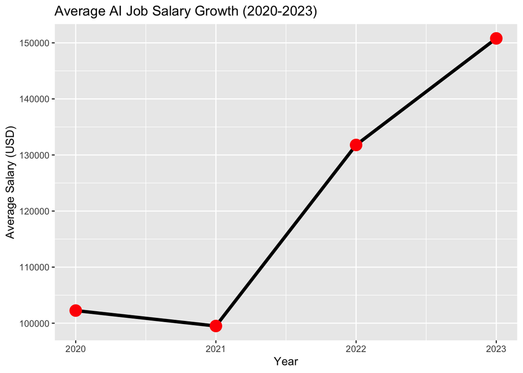

```r
salary_per_year %>%
ggplot(aes(x = as.numeric(year), y = avg_salary)) +
  geom_line(size = 1.5, color = "black") +
  geom_point(size = 5, color = "red") +
  labs(title = "Average AI Job Salary Growth (2020-2023)", x = "Year", y = "Average Salary (USD)")
```

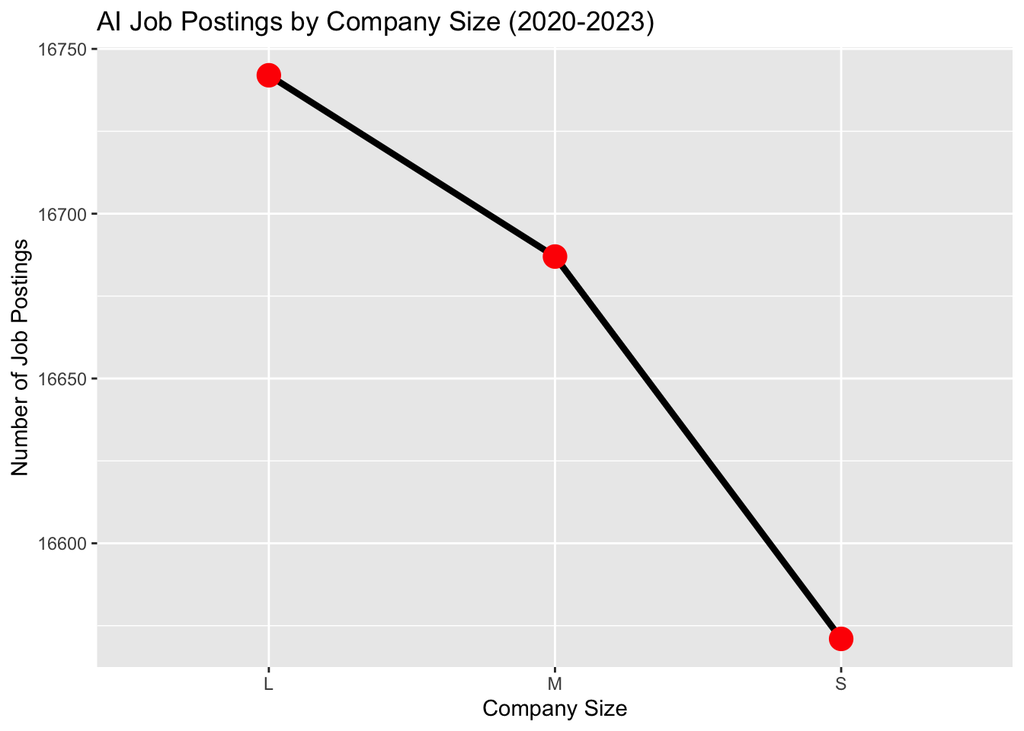

```r
ggplot(company_summary, aes(x = company_size, y = total_jobs, group = 1)) +
  geom_line(size = 1.5, color = "black") +
  geom_point(size = 5, color = "red") +
  labs(title = "AI Job Postings by Company Size (2020-2023)", x = "Company Size", y = "Number of Job Postings")
```

================================================================================================================================================================

## FINN’S RESEARCH QUESTION (2): Which industries have experienced the greatest increase in AI-related job openings?

# Loading and checking data

```r
insights <- read_delim("/Users/Aarul/UW/INFO 201/Final Project/INFO201_Final_Project/ai_job_market_insights.csv")
head(insights)
```

```
## # A tibble: 6 × 10
##   Job_Title     Industry Company_Size Location AI_Adoption_Level Automation_Risk
##   <chr>         <chr>    <chr>        <chr>    <chr>             <chr>
## 1 Cybersecurit… Enterta… Small        Dubai    Medium            High
## 2 Marketing Sp… Technol… Large        Singapo… Medium            High
## 3 AI Researcher Technol… Large        Singapo… Medium            High
## 4 Sales Manager Retail   Small        Berlin   Low               High
## 5 Cybersecurit… Enterta… Small        Tokyo    Low               Low
## 6 UX Designer   Educati… Large        San Fra… Medium            Medium
## # ℹ 4 more variables: Required_Skills <chr>, Salary_USD <dbl>,
## #   Remote_Friendly <chr>, Job_Growth_Projection <chr>
```

```r
trends <- read_delim("/Users/Aarul/UW/INFO 201/Final Project/INFO201_Final_Project/AI_Job_Posting_Trends 2.csv")
head(trends)
```

```
## # A tibble: 6 × 18
##   job_id job_title   salary_usd salary_currency experience_level employment_type
##   <chr>  <chr>            <dbl> <chr>           <chr>            <chr>
## 1 XYZ001 AI Softwar…      76857 EUR             Executive        Contract
## 2 XYZ002 AI Archite…      68860 GBP             Entry_Level      Freelancer
## 3 XYZ003 AI Archite…     120112 EUR             Mid              Part Time
## 4 XYZ004 Principal …     112812 EUR             Entry_Level      Full Time
## 5 XYZ005 AI Researc…      63245 USD             Entry_Level      Part Time
## 6 XYZ006 AI Softwar…     153372 USD             Entry_Level      Contract
## # ℹ 12 more variables: company_location <chr>, company_size <chr>,
## #   employee_residence <chr>, remote_ratio <dbl>, required_skills <chr>,
## #   education_required <chr>, years_experience <dbl>, industry <chr>,
## #   posting_date <chr>, benefits_score <dbl>, company_name <chr>,
## #   remote_category <chr>
```

#Cleaning the data

```r
insights_clean <- insights %>%
  distinct()

trends_clean <- trends %>%
  mutate(posting_date = as.Date(posting_date, format = "%m/%d/%y")) %>%
  distinct()
```

#Updating data so I can use it for merging and graphing

```r
trends_per_month <- trends_clean %>%
  mutate(year = format(posting_date, "%Y"), month = format(posting_date, "%m")) %>%
  group_by(industry, year, month) %>%
  summarize(postings_count = n()) #counts number of rows per group
industry_increase <- trends_per_month %>%
  group_by(industry) %>%
  summarize(first = first(postings_count), last = last(postings_count), increase = last - first) %>%
  arrange(desc(increase))
```

```r
head(trends_per_month)
```

```
## # A tibble: 6 × 4
## # Groups:   industry, year [1]
##   industry   year  month postings_count
##   <chr>      <chr> <chr>          <int>
## 1 Automotive 2019  01                61
## 2 Automotive 2019  02                43
## 3 Automotive 2019  03                52
## 4 Automotive 2019  04                48
## 5 Automotive 2019  05                73
## 6 Automotive 2019  06                49
```

```r
head(industry_increase)
```

```
## # A tibble: 6 × 4
##   industry    first  last increase
##   <chr>       <int> <int>    <int>
## 1 Healthcare     51    74       23
## 2 Finance        46    61       15
## 3 Energy         53    64       11
## 4 Real Estate    55    62        7
## 5 Media          52    57        5
## 6 Technology     56    54       -2
```

#Merging the data

```r
merged <- merge(industry_increase, trends_per_month, by = "industry")
head(merged)
```

```
##     industry first last increase year month postings_count
## 1 Automotive    61   50      -11 2023    10             62
## 2 Automotive    61   50      -11 2023    12             50
## 3 Automotive    61   50      -11 2020    06             43
## 4 Automotive    61   50      -11 2023    09             51
## 5 Automotive    61   50      -11 2021    04             59
## 6 Automotive    61   50      -11 2023    11             49
```

```r
merged <- merged %>%
  arrange(desc(increase))
```

#This graph shows the job postings for the top 5 growing industries over the years

```r
yearly_increase <- merged %>%
  group_by(industry, year) %>%
  summarize(yearly_total = sum(postings_count)) %>%
  arrange(industry, year)
```

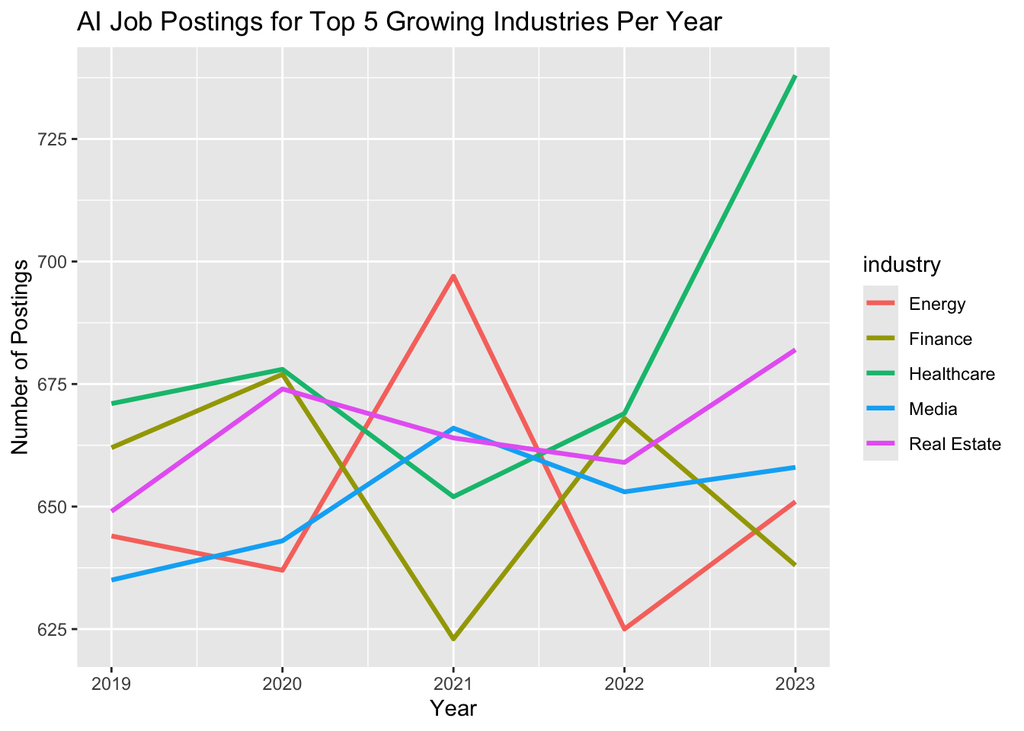

```r
top5 <- merged %>%
  distinct(industry, increase) %>%
  arrange(desc(increase)) %>%
  slice(1:5) %>%
  pull(industry)

yearly_increase_top5 <- yearly_increase %>%
  filter(industry %in% top5)

ggplot(yearly_increase_top5, aes(x = as.numeric(year), y = yearly_total, color = industry)) +
  geom_line(linewidth = 1.1) +
  labs(
    title = "AI Job Postings for Top 5 Growing Industries Per Year",
    x = "Year",
    y = "Number of Postings"
  )
```

#This graph uses merged data to show increase of AI job postings by industry per year

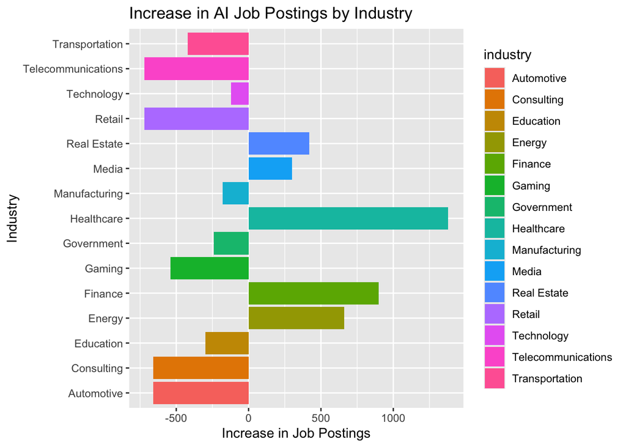

```r
ggplot(merged, aes(x = industry, y = increase, fill = industry)) +
  geom_col() +
  coord_flip() +
  labs(
    title = "Increase in AI Job Postings by Industry",
    x = "Industry",
    y = "Increase in Job Postings"
  )
```

================================================================================================================================================================ ## WAYNE’S RESEARCH QUESTION: How has AI-related hiring shifted in non-tech sectors?

## Cleaning and Merging

```r
lowercase_clean <- function(df) {
  names(df) <- tolower(names(df))
  df
}

job_postings <- job_postings %>%
  rename(location = company_location)

insights <- lowercase_clean(insights)

names(job_postings)
```

```
##  [1] "job_id"             "job_title"          "salary_usd"
##  [4] "salary_currency"    "experience_level"   "employment_type"
##  [7] "location"           "company_size"       "employee_residence"
## [10] "remote_ratio"       "required_skills"    "education_required"
## [13] "years_experience"   "industry"           "posting_date"
## [16] "benefits_score"     "company_name"       "remote_category"
```

```r
names(insights)
```

```
##  [1] "job_title"             "industry"              "company_size"
##  [4] "location"              "ai_adoption_level"     "automation_risk"
##  [7] "required_skills"       "salary_usd"            "remote_friendly"
## [10] "job_growth_projection"
```

```r
merged_data <- job_postings %>%
  left_join(insights, by = "job_title", relationship = "many-to-many")

merged_data <- merged_data %>%
  select(-ends_with(".y"))

merged_data <- merged_data %>%
  mutate(
    remote_friendly = ifelse(remote_category == "Fully Remote", "Yes", remote_friendly),
    remote_friendly = ifelse(remote_category == "On-site", "No", remote_friendly),
    remote_friendly = ifelse(remote_category == "Hybrid", "Hybrid", remote_friendly)
      )

merged_data
```

```
## # A tibble: 169,255 × 22
##    job_id job_title                salary_usd.x salary_currency experience_level
##    <chr>  <chr>                           <dbl> <chr>           <chr>
##  1 XYZ001 AI Software Engineer            76857 EUR             Executive
##  2 XYZ002 AI Architect                    68860 GBP             Entry_Level
##  3 XYZ003 AI Architect                   120112 EUR             Mid
##  4 XYZ004 Principal Data Scientist       112812 EUR             Entry_Level
##  5 XYZ005 AI Research Scientist           63245 USD             Entry_Level
##  6 XYZ006 AI Software Engineer           153372 USD             Entry_Level
##  7 XYZ007 Principal Data Scientist       118550 GBP             Entry_Level
##  8 XYZ008 ML Ops Engineer                 68810 EUR             Entry_Level
##  9 XYZ009 Principal Data Scientist       145273 EUR             Entry_Level
## 10 XYZ010 Computer Vision Engineer        71362 GBP             Mid
## # ℹ 169,245 more rows
## # ℹ 17 more variables: employment_type <chr>, location.x <chr>,
## #   company_size.x <chr>, employee_residence <chr>, remote_ratio <dbl>,
## #   required_skills.x <chr>, education_required <chr>, years_experience <dbl>,
## #   industry.x <chr>, posting_date <chr>, benefits_score <dbl>,
## #   company_name <chr>, remote_category <chr>, ai_adoption_level <chr>,
## #   automation_risk <chr>, remote_friendly <chr>, job_growth_projection <chr>
```

## Sort data by the amount of times a job got labeled “Growth” or “Decline”

```r
growth_count <- insights %>%
  filter(!is.na(job_growth_projection)) %>%
  count(job_title, job_growth_projection) %>%
  group_by(job_title) %>%
  mutate(total = sum(n))
```

## Top jobs with the most amount of “Growth” labels

```r
top_jobs <- growth_count %>%
  filter(job_growth_projection == "Growth") %>%
  arrange(desc(n)) %>%
  head(10)
```

## Industries with the most job postings

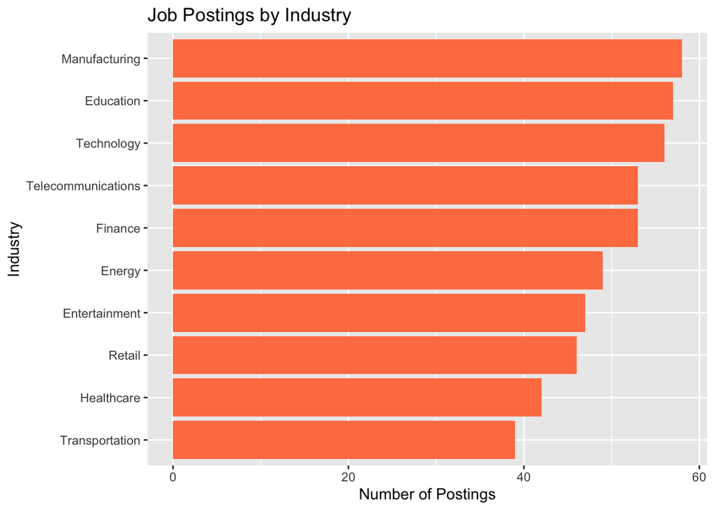

```r
insights %>%
  count(industry) %>%
  ggplot(aes(x = reorder(industry, n), y = n)) +
  geom_col(fill = "coral") +
  coord_flip() +
  labs(
    title = "Job Postings by Industry",
    x = "Industry",
    y = "Number of Postings"
  )
```

## Visualization of AI Job Roles with the most “Growth” labels by percentage

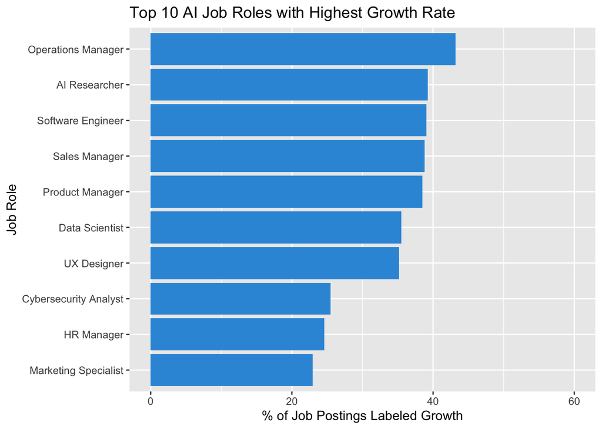

```r
growth_percent <- insights %>%
  filter(!is.na(job_growth_projection)) %>%
  count(job_title, job_growth_projection) %>%
  group_by(job_title) %>%
    mutate(total = sum(n)) %>%
    mutate(percentage = (n / total) * 100) %>%
  filter(job_growth_projection == "Growth", total >= 2) %>%
  arrange(desc(percentage)) %>%
  head(10)

ggplot(growth_percent, aes(x = reorder(job_title, percentage), y = percentage)) +
  geom_col(fill = "#3498db") +
  coord_flip() +
  ylim(0, 60) +
  labs(
    title = "Top 10 AI Job Roles with Highest Growth Rate",
    x = "Job Role",
    y = "% of Job Postings Labeled Growth"
  )
```

## Visualization of Job Growth Trajectory VS AI Adoption Level

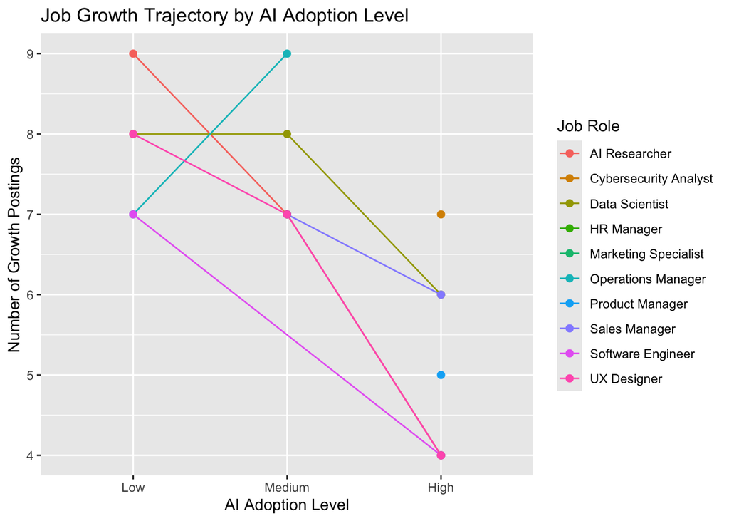

```r
growth_by_adoption <- insights %>%
  filter(!is.na(job_growth_projection), !is.na(ai_adoption_level)) %>%
    count(job_title, ai_adoption_level, job_growth_projection) %>%
    filter(job_growth_projection == "Growth") %>%
    arrange(ai_adoption_level, desc(n)) %>%
    group_by(ai_adoption_level) %>%
    slice_max(n, n = 5) %>%
    ungroup()

  ggplot(growth_by_adoption, aes(x = ai_adoption_level, y = n, color = job_title, group = job_title)) +
    geom_line() +
    geom_point(size = 2) +
    scale_x_discrete(limits = c("Low", "Medium", "High")) +
    labs(
      title = "Job Growth Trajectory by AI Adoption Level",
      x = "AI Adoption Level",
      y = "Number of Growth Postings",
      color = "Job Role"
    )
```

## ESHAAN’S RESEARCH QUESTION: What countries are leading in AI job growth relative to GDP or population?

## Load libraries

```r
library(tidyverse)
library(readr)
library(dplyr)
library(ggplot2)
```

## Load datasets for Question 4

```r
aiJobs <- read_csv("/Users/Aarul/UW/INFO 201/Final Project/INFO201_Final_Project/data_science_salaries.csv")
countries <- read_csv("/Users/Aarul/UW/INFO 201/Final Project/INFO201_Final_Project/countries of the world - Eshaan.csv")
head(aiJobs)
```

```
## # A tibble: 6 × 11
##   job_title      experience_level employment_type work_models work_year
##   <chr>          <chr>            <chr>           <chr>           <dbl>
## 1 Data Engineer  Mid-level        Full-time       Remote           2024
## 2 Data Engineer  Mid-level        Full-time       Remote           2024
## 3 Data Scientist Senior-level     Full-time       Remote           2024
## 4 Data Scientist Senior-level     Full-time       Remote           2024
## 5 BI Developer   Mid-level        Full-time       On-site          2024
## 6 BI Developer   Mid-level        Full-time       On-site          2024
## # ℹ 6 more variables: employee_residence <chr>, salary <dbl>,
## #   salary_currency <chr>, salary_in_usd <dbl>, company_location <chr>,
## #   company_size <chr>
```

```r
head(countries)
```

```
## # A tibble: 6 × 20
##   Country        Region       Population `Area (sq. mi.)` Pop. Density (per sq…¹
##   <chr>          <chr>             <dbl>            <dbl> <chr>
## 1 Afghanistan    ASIA (EX. N…   31056997           647500 48,0
## 2 Albania        EASTERN EUR…    3581655            28748 124,6
## 3 Algeria        NORTHERN AF…   32930091          2381740 13,8
## 4 American Samoa OCEANIA           57794              199 290,4
## 5 Andorra        WESTERN EUR…      71201              468 152,1
## 6 Angola         SUB-SAHARAN…   12127071          1246700 9,7
## # ℹ abbreviated name: ¹`Pop. Density (per sq. mi.)`
## # ℹ 15 more variables: `Coastline (coast/area ratio)` <chr>,
## #   `Net migration` <chr>, `Infant mortality (per 1000 births)` <dbl>,
## #   `GDP ($ per capita)` <dbl>, `Literacy (%)` <dbl>,
## #   `Phones (per 1000)` <chr>, `Arable (%)` <chr>, `Crops (%)` <chr>,
## #   `Other (%)` <dbl>, Climate <dbl>, Birthrate <dbl>, Deathrate <dbl>,
## #   Agriculture <chr>, Industry <chr>, Service <chr>
```

## Clean countries dataset

```r
countriesClean <- countries %>%
  mutate(
    Country = str_trim(Country),
    Population = as.numeric(gsub("[^0-9]", "", Population)),
    GDP_per_capita = as.numeric(gsub("[^0-9]", "", `GDP ($ per capita)`)),
    Total_GDP = GDP_per_capita * Population
  ) %>%
  select(Country, Region, Population, GDP_per_capita, Total_GDP) %>%
  filter(!is.na(Population), !is.na(Total_GDP))
```

## Count AI jobs by country

```r
aiByCountry <- aiJobs %>%
  count(employee_residence, name = "jobCount") %>%
  arrange(desc(jobCount))

head(aiByCountry, 20)
```

```
## # A tibble: 20 × 2
##    employee_residence jobCount
##    <chr>                 <int>
##  1 United States          5305
##  2 United Kingdom          401
##  3 Canada                  241
##  4 Germany                  71
##  5 India                    70
##  6 Spain                    67
##  7 France                   53
##  8 Australia                29
##  9 Portugal                 28
## 10 Netherlands              21
## 11 Italy                    20
## 12 Brazil                   19
## 13 Colombia                 14
## 14 Greece                   13
## 15 Nigeria                  12
## 16 Poland                   11
## 17 Ireland                  10
## 18 Mexico                   10
## 19 Argentina                 9
## 20 Estonia                   8
```

## Check which countries won’t match

```r
aiByCountry %>%
  filter(!employee_residence %in% countriesClean$Country) %>%
  select(employee_residence, jobCount)
```

```
## # A tibble: 3 × 2
##   employee_residence       jobCount
##   <chr>                       <int>
## 1 Central African Republic        2
## 2 South Korea                     2
## 3 Bosnia and Herzegovina          1
```

## Merge datasets and calculate metrics

```r
finalData <- aiByCountry %>%
  inner_join(countriesClean, by = c("employee_residence" = "Country")) %>%
  mutate(
    jobsPerMillion = (jobCount / Population) * 1e6,
    jobsPerBillionGdp = (jobCount / (Total_GDP / 1e9))
  ) %>%
  rename(Country = employee_residence)

nrow(finalData)
```

```
## [1] 84
```

```r
head(finalData)
```

```
## # A tibble: 6 × 8
##   Country     jobCount Region Population GDP_per_capita Total_GDP jobsPerMillion
##   <chr>          <int> <chr>       <dbl>          <dbl>     <dbl>          <dbl>
## 1 United Sta…     5305 NORTH…  298444215          37800   1.13e13        17.8
## 2 United Kin…      401 WESTE…   60609153          27700   1.68e12         6.62
## 3 Canada           241 NORTH…   33098932          29800   9.86e11         7.28
## 4 Germany           71 WESTE…   82422299          27600   2.27e12         0.861
## 5 India             70 ASIA … 1095351995           2900   3.18e12         0.0639
## 6 Spain             67 WESTE…   40397842          22000   8.89e11         1.66
## # ℹ 1 more variable: jobsPerBillionGdp <dbl>
```

## Visualization 1: Top countries by absolute job count

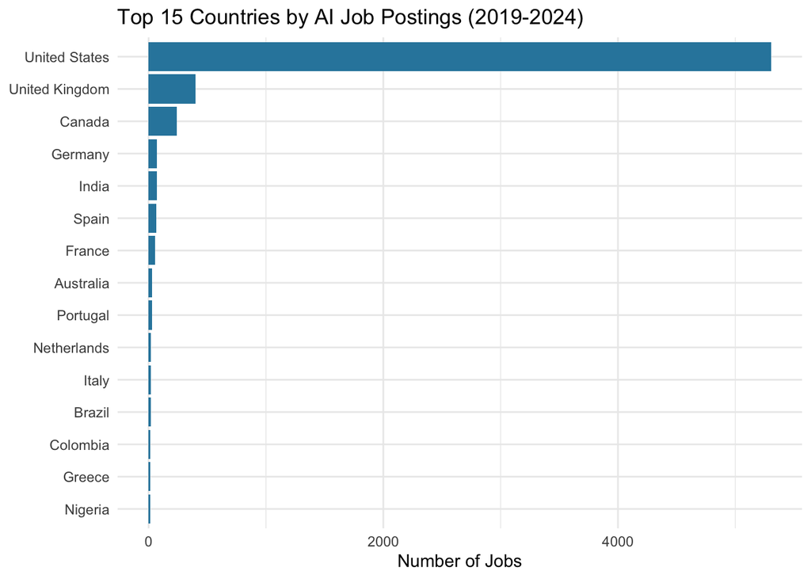

```r
finalData %>%
  slice_max(jobCount, n = 15) %>%
  ggplot(aes(x = reorder(Country, jobCount), y = jobCount)) +
  geom_col(fill = "#2E86AB") +
  coord_flip() +
  labs(
    title = "Top 15 Countries by AI Job Postings (2019-2024)",
    x = NULL,
    y = "Number of Jobs"
  ) +
  theme_minimal()
```

## Visualization 2: Jobs per million population

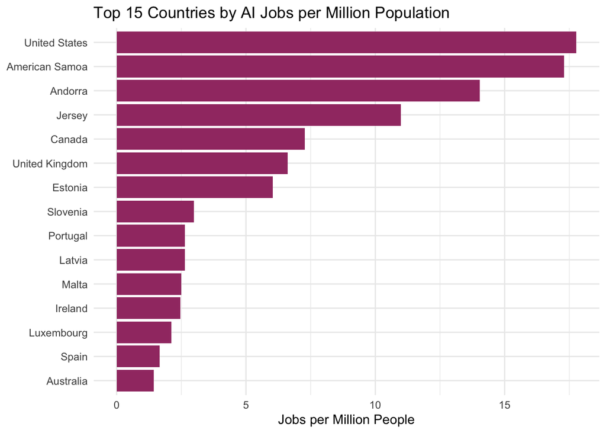

```r
finalData %>%
  slice_max(jobsPerMillion, n = 15) %>%
  ggplot(aes(x = reorder(Country, jobsPerMillion), y = jobsPerMillion)) +
  geom_col(fill = "#A23B72") +
  coord_flip() +
  labs(
    title = "Top 15 Countries by AI Jobs per Million Population",
    x = NULL,
    y = "Jobs per Million People"
  ) +
  theme_minimal()
```

## Visualization 3: Jobs per billion GDP

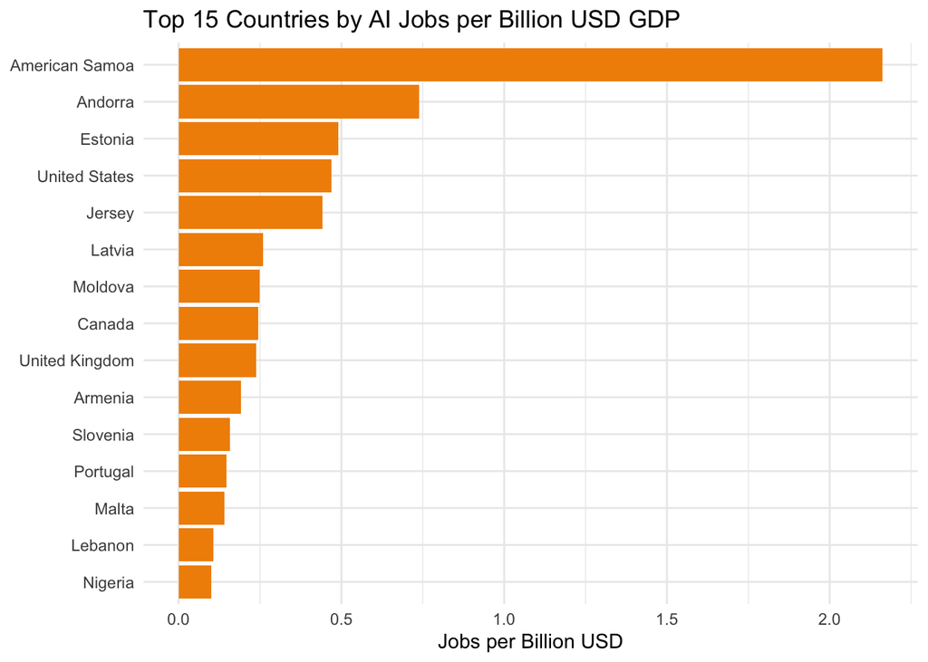

```r
finalData %>%
  filter(jobsPerBillionGdp < Inf) %>%
  slice_max(jobsPerBillionGdp, n = 15) %>%
  ggplot(aes(x = reorder(Country, jobsPerBillionGdp), y = jobsPerBillionGdp)) +
  geom_col(fill = "#F18F01") +
  coord_flip() +
  labs(
    title = "Top 15 Countries by AI Jobs per Billion USD GDP",
    x = NULL,
    y = "Jobs per Billion USD"
  ) +
  theme_minimal()
```

## Summary statistics table

```r
finalData %>%
  arrange(desc(jobCount)) %>%
  select(Country, jobCount, jobsPerMillion, jobsPerBillionGdp) %>%
  mutate(
    jobsPerMillion = round(jobsPerMillion, 1),
    jobsPerBillionGdp = round(jobsPerBillionGdp, 2)
  ) %>%
  head(15)
```

```
## # A tibble: 15 × 4
##    Country        jobCount jobsPerMillion jobsPerBillionGdp
##    <chr>             <int>          <dbl>             <dbl>
##  1 United States      5305           17.8              0.47
##  2 United Kingdom      401            6.6              0.24
##  3 Canada              241            7.3              0.24
##  4 Germany              71            0.9              0.03
##  5 India                70            0.1              0.02
##  6 Spain                67            1.7              0.08
##  7 France               53            0.9              0.03
##  8 Australia            29            1.4              0.05
##  9 Portugal             28            2.6              0.15
## 10 Netherlands          21            1.3              0.04
## 11 Italy                20            0.3              0.01
## 12 Brazil               19            0.1              0.01
## 13 Colombia             14            0.3              0.05
## 14 Greece               13            1.2              0.06
## 15 Nigeria              12            0.1              0.1
```

================================================================================================================================================================

## # 1. Abstract

### In this paper we analyze the growth in AI-related positions from 2020 through 2023, using both job postings and salary data from Kaggle. The purpose of our paper is to answer four research questions; (1) How has demand for AI-related roles grown over the past 5 years? (2) Which industries have experienced the greatest increase in AI-related job openings? (3) How has AI-related hiring shifted in non-tech sectors? (4) What countries are leading in AI job growth relative to GDP or population? We find that there was a 47.5% increase in the average salary of people working in AI jobs over this period, from an average of $102,251 in 2020 to $150,791 in 2023. This indicates that employers continue to be highly interested in acquiring AI talent. Our results also indicate a fairly even distribution of hiring activity among all firm size categories as 16,742 AI related job postings were placed by larger firms versus 16,571 by smaller firms. In addition, our analysis of hiring by sector indicates that each sector has had different rates of adopting AI technology and we also identify the presence of concentrations in markets for AI talent.

## # 2. Introduction

## Background Context:

### AI has evolved dramatically from a laboratory experiment to a major source of business innovation and growth. In the last five years, the rate of AI adoption has grown significantly across many industries, and the rate of change is transforming workforce skills and needs. The increasing investment in AI capabilities at the company level has created unprecedented demand for individuals with the ability to develop and deploy AI systems. The change is occurring across virtually all sectors including, healthcare, financial services, manufacturing and retail. All of these sectors are now using AI within their operations.

### The AI job market represents a key point of convergence between technological innovation and economic opportunity. Organizations competing for the most capable professionals to develop, build, and use machine learning, natural language processing, and computer vision systems are increasingly aggressive in their pursuit of such talent. This competition is evident through increases in salary levels, greater numbers of job postings, new specialization opportunities and changing expectations regarding required skills. Research on previous studies documenting the broad increase in number of technology jobs and the establishment of data science as a recognized profession, however, has not examined in detail the specifics of AI related professional roles, including trends in compensation, geographic distribution, industry adoption, and organizational preference.

### Understanding these changes has significant implications for several types of stakeholders. Job seekers will benefit from having access to data that informs career decisions and investments in skill development. Educational institutions will be able to create curricula aligned with actual market demand. Policymakers will have access to information needed to inform workforce development initiatives. Finally, business leaders will have benchmarking tools available to support their strategic efforts to acquire talented employees. Our analysis will provide this type of information by analyzing a comprehensive set of data spanning the period from 2020 to 2023; a time during which AI was advancing at a very high rate, and was being adopted by organizations at an increasingly rapid pace.

## Research Objectives:

## Research Question 1 (Aarul Motiani): How has demand for AI-related roles grown over the past 5 years?

### Demand can be measured using two main ways; job postings and salaries. Since we have analyzed 50,000 job postings and salary data, we can find out if an increase in employers’ ability to pay employees more money is evidence that there is actually more demand in the labor market for AI skills. Both of these elements address the amount of and the quality of the demand.

## Research Question 2 (Finn Caughie): Which industries have experienced the greatest increase in AI-related job openings?

### Job postings data from several months will help us to see the trend of which industries are developing AI related hiring practices. We will also determine if AI growth is limited to tech companies or is more widely spread throughout various other industries. This research will also help us to understand the type of industries that are making the heaviest investments into their AI capabilities.

## Research Question 3 (Wayne Zhao): How has AI-related hiring shifted in non-tech sectors?

### The purpose of this section is to look at industries that were traditionally outside the scope of the technology sector and better to understand the level of AI adoption within those industries. This section will address whether AI-related positions are still specialized or have been adopted as common across all areas of the business. The sections on adoption rates, the likelihood of job automation and work-at-home arrangements will be used to study how non-tech industries have developed unique approaches to acquiring AI talent.

## Research Question 4 (Eshaan Garg): What countries are leading in AI job growth relative to GDP or population?

### This section will be used to compare the number of AI-related jobs that exist in each country in relation to its population size or the size of the economy. This comparison will allow us to differentiate between large economies that may have an enormous number of total jobs available, versus small countries that have a significantly larger proportion of the workforce with AI related skills. These comparisons will help us to understand the global distribution of AI expertise.

## # 3. Data Sources

## AI Jobs Posting Trends from 2019–2023 Source:

## Kaggle dataset: AI Jobs Posting Trends from 2019–2023. https://www.kaggle.com/datasets/pranjali1121/ai-jobs-posting-trends-from-2019-2023

## Who collected the data: This dataset was uploaded by the user pranjali1121 and is on Kaggle which is a platform where community members can post datasets for people to use freely. Usage permissions: The dataset is publicly available on Kaggle. It can be freely accessed and downloaded by anyone with a Kaggle account. There are no restricted usage terms outside of the standard Kaggle terms (not for redistribution outside Kaggle without proper citation).

## What it represents: It shows the trends in AI-related job postings from 2019–2023, showing how demand for AI skills has changed over time. The data typically includes counts or indicators of job postings by year.

## Why we chose it: This dataset directly supports research questions about how AI job demand has changed over time, giving us a view of hiring trends and helping analyze growth patterns in the AI labor market.

## AI-Powered Job Market Insights Source:

## Kaggle dataset: AI-Powered Job Market Insights. https://www.kaggle.com/datasets/uom190346a/ai-powered-job-market-insights

## Who collected the data: This dataset was provided by the user uom190346a.

## Usage permissions: It’s freely accessible on Kaggle for anyone to download and use based on Kaggle’s standard terms. There are no restrictions (non-commercial only) listed on the page.

## What it represents: The dataset has detailed job listings with things like job title, industry, company size, AI adoption level, automation risk, required skills, salary ranges, and growth projection which was useful for understanding AI-related jobs.

## Why chosen: This dataset supports our research questions about current AI job market characteristics, such as what skills are in demand, what industries are hired, and how job attributes vary with AI adoption.

## Countries of the World Dataset Source:

## Kaggle dataset: Countries of the World https://www.kaggle.com/datasets/fernandol/countries-of-the-world

## Who collected the data: The dataset was uploaded by the Kaggle user fernandol, who compiled country-level statistics originally sourced from the CIA World Factbook.

## Usage permissions: The dataset is publicly available and free to download from Kaggle. Anyone with a Kaggle account can access it, with no special restrictions beyond standard Kaggle usage and citation rules.

## What it represents: This dataset includes demographic, economic, and geographic indicators for countries around the world such as population, area, GDP, literacy rates, and other statistics.

## Why chosen: This dataset helps support research questions related to comparing AI job growth across countries, especially when adjusting for factors like GDP or population size. It provides the baseline national statistics needed to standardize and compare AI job expansion globally.

[output not shown]

# 5. Method & Results

## Research Q1: How has demand for AI-related roles grown over the past 5 years?

## Data / Visualization:

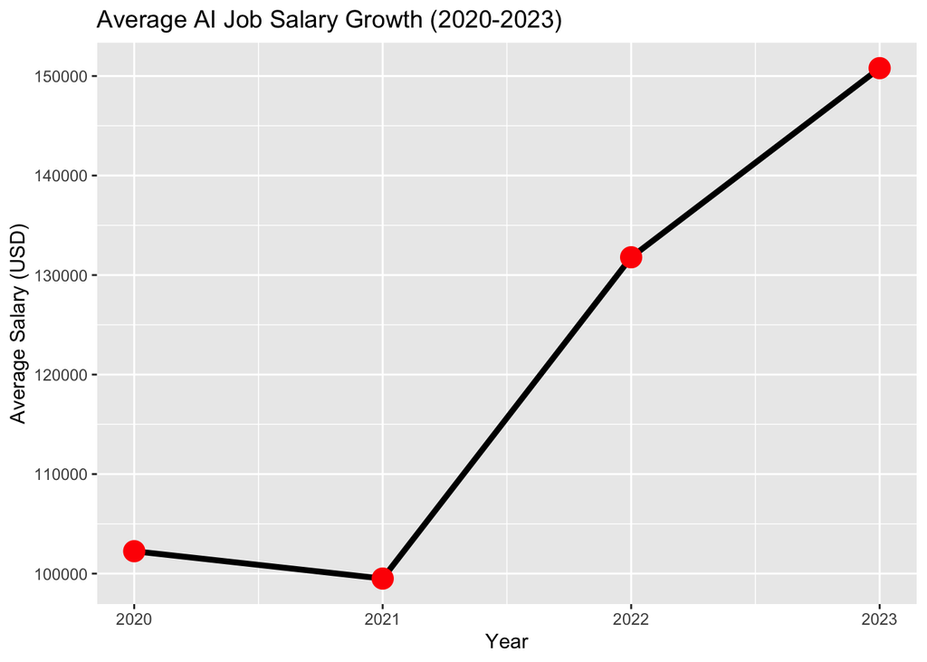

```r
salary_per_year %>%
ggplot(aes(x = as.numeric(year), y = avg_salary)) +
  geom_line(size = 1.5, color = "black") +
  geom_point(size = 5, color = "red") +
  labs(title = "Average AI Job Salary Growth (2020-2023)", x = "Year", y = "Average Salary (USD)")
```

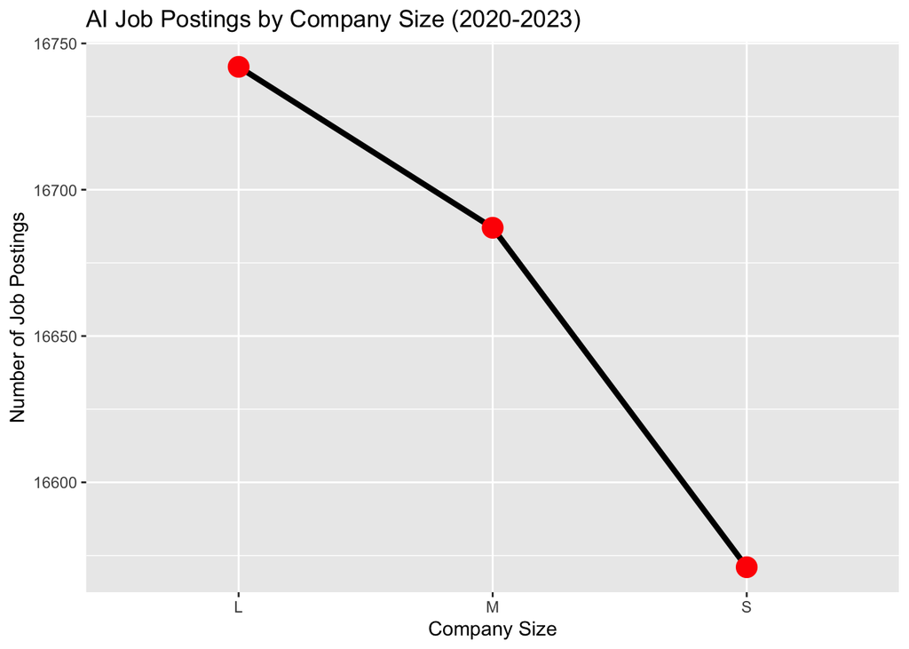

```r
ggplot(company_summary, aes(x = company_size, y = total_jobs, group = 1)) +
  geom_line(size = 1.5, color = "black") +
  geom_point(size = 5, color = "red") +
  labs(title = "AI Job Postings by Company Size (2020-2023)", x = "Company Size", y = "Number of Job Postings")
```

### To measure the overall demand, we merged yearly job posting counts with annual salary averages from 2020-2023. We split the results using 2 visualizations, one involving year-over-year growth in average AI salaries, and another showing the distribution of job postings across company sizes. These in combination help us analyze the quality and intensity of the markets’ demand for AI-related roles.

## Findings:

### The line graph of average salary growth demonstrates a rise in salary for AI (47.5% increase) and its related roles, showing market demand and employers’ increasing willingness to pay employees with AI expertise. Furthermore, our company vs size comparison shows that demand is distributed across organizations regardless of size. Larger companies posted 16,742 AI-related roles while smaller companies posted 16,571, which is a minimal difference. Suggesting that AI adoption and hiring are not only exclusive to big tech companies, but small companies are also adamant in recruiting AI workers and involving themselves in the world of AI.

## Limitations:

### Despite clear patterns, the analysis may understate real hiring levels. Job posting datasets reflect only publicly advertised positions and exclude internal hiring channels, contract platforms, or informal recruitment. Salary data may also be skewed toward countries and industries that post compensation more transparently. In addition, the dataset covers only 2020–2023, limiting our ability to determine whether recent trends represent short-term acceleration or long-term structural change.

## Potential Improvements:

### Future research could incorporate additional job board datasets, extend the time range for trend analysis, and include skill-specific breakdowns (e.g., demand for machine-learning engineers vs. data analysts). Adding measures of seniority and job type would also help distinguish between growth in entry-level roles versus high-skill specialist positions.

## Research Q2: Which industries have experienced the greatest increase in AI-related job openings?

## Data / Visualization:

```r
yearly_increase <- merged %>%
  group_by(industry, year) %>%
  summarize(yearly_total = sum(postings_count)) %>%
  arrange(industry, year)
```

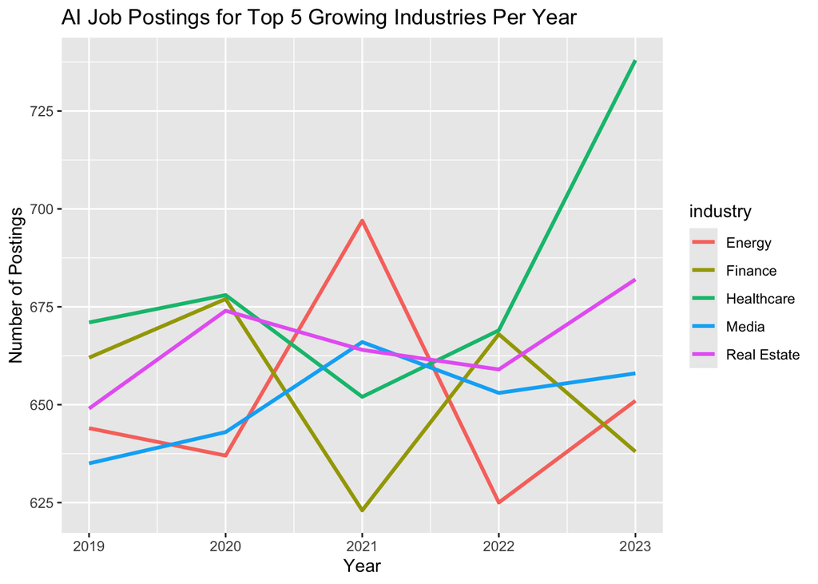

```r
top5 <- merged %>%
  distinct(industry, increase) %>%
  arrange(desc(increase)) %>%
  slice(1:5) %>%
  pull(industry)

yearly_increase_top5 <- yearly_increase %>%
  filter(industry %in% top5)

ggplot(yearly_increase_top5, aes(x = as.numeric(year), y = yearly_total, color = industry)) +
  geom_line(linewidth = 1.1) +
  labs(
    title = "AI Job Postings for Top 5 Growing Industries Per Year",
    x = "Year",
    y = "Number of Postings"
  )
```

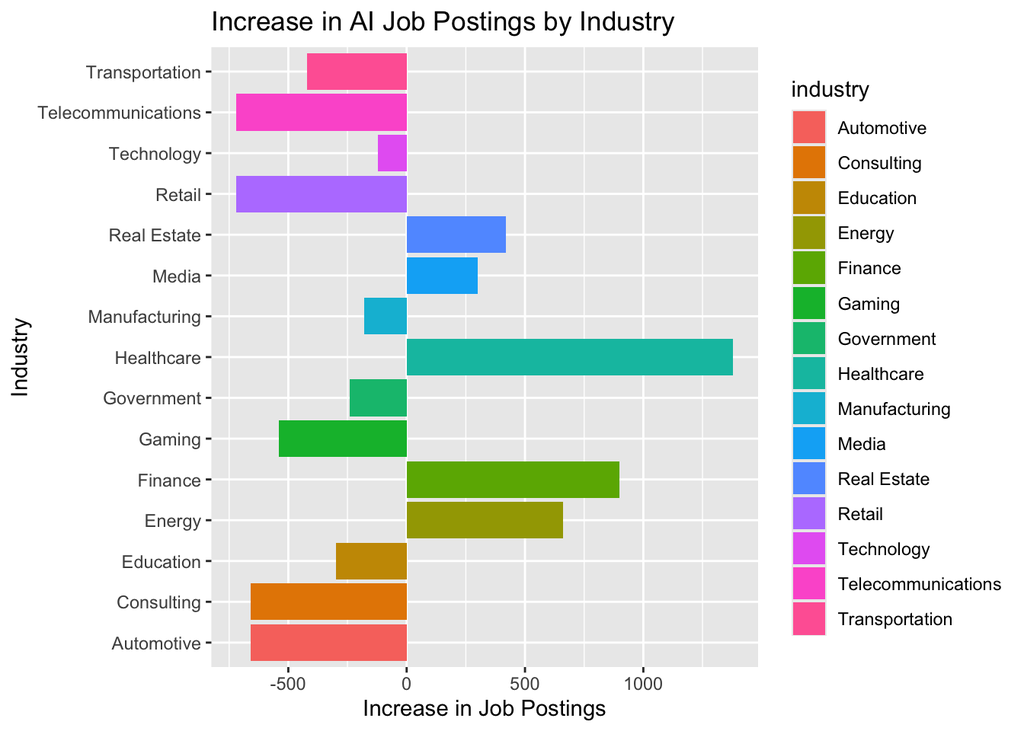

```r
ggplot(merged, aes(x = industry, y = increase, fill = industry)) +
  geom_col() +
  coord_flip() +
  labs(
    title = "Increase in AI Job Postings by Industry",
    x = "Industry",
    y = "Increase in Job Postings"
  )
```

### Limitations: A limitation of the analysis is that it only shows AI related job postings, and it might not capture overall industry demand. Additionally, the method of calculating growth by comparing the first/last monthly posting counts can be sensitive to missing or irregular data, and the postings by month will lead to smoothing of seasonal fluctuations/spikes. Also, industry labels may vary, splitting related sectors and affecting comparisons. Last, although the insights dataset was cleaned, it was not fully integrated into the analysis, limiting the ability to examine factors such as salary, AI adoption, or automation risk.

### Potential Improvements: Integrating the insights dataset would allow us to have a multivariable analysis to explore how factors like salary, AI adoption, or automation risk relate to job growth. Visualization could be enhanced by smoothing data or moving some averages to better show patterns and trends. Additionally, verifying and standardizing industry categories, detecting anomalies or outliers, and weighing postings by industry workforce size could give a better understanding of which sectors are experiencing the most significant growth in AI-related job openings.

## Research Q3: How has AI-related hiring shifted in non-tech sectors

## Data / Visualization:

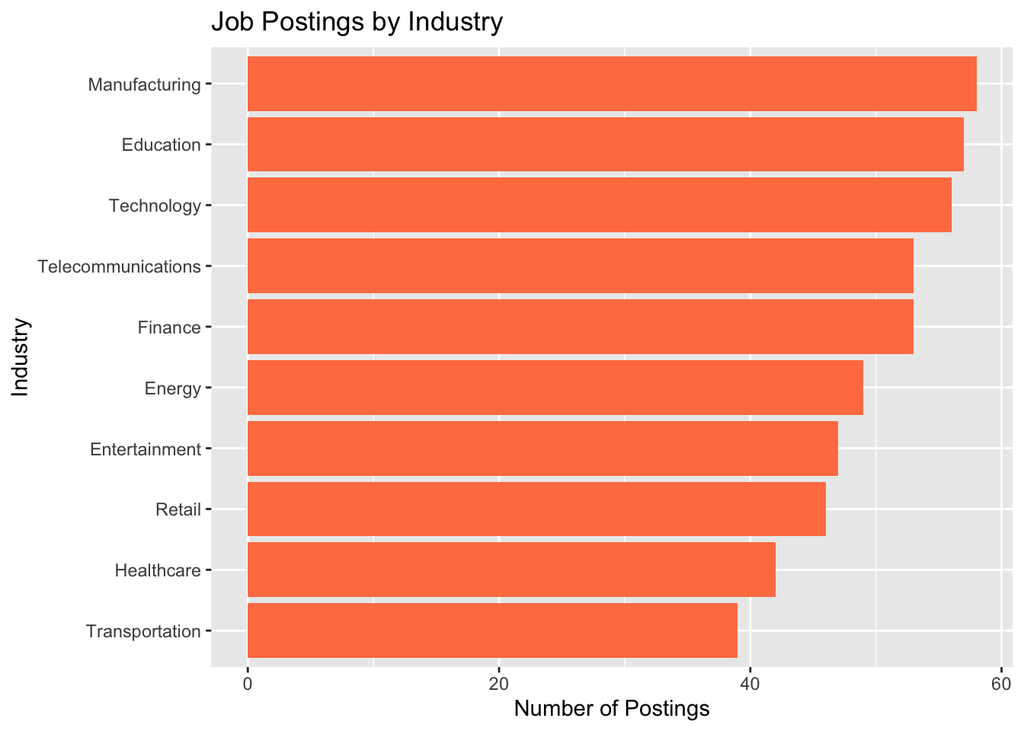

```r
insights %>%
  count(industry) %>%
  ggplot(aes(x = reorder(industry, n), y = n)) +
  geom_col(fill = "coral") +
  coord_flip() +
  labs(
    title = "Job Postings by Industry",
    x = "Industry",
    y = "Number of Postings"
  )
```

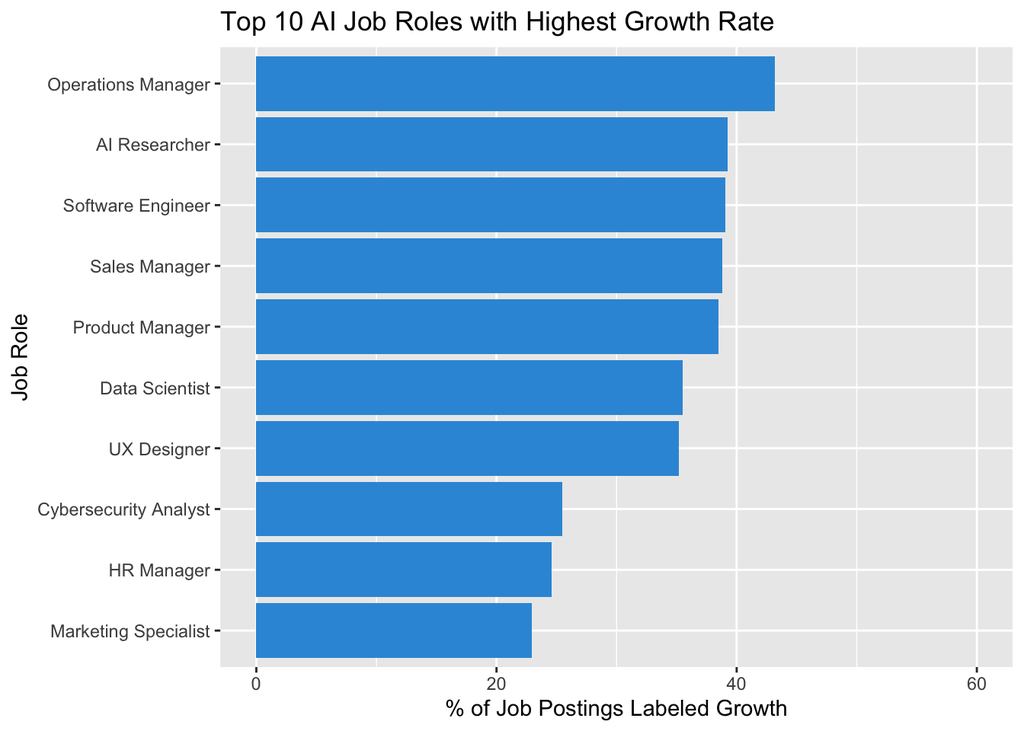

```r
growth_percent <- insights %>%
  filter(!is.na(job_growth_projection)) %>%
  count(job_title, job_growth_projection) %>%
  group_by(job_title) %>%
    mutate(total = sum(n)) %>%
    mutate(percentage = (n / total) * 100) %>%
  filter(job_growth_projection == "Growth", total >= 2) %>%
  arrange(desc(percentage)) %>%
  head(10)

ggplot(growth_percent, aes(x = reorder(job_title, percentage), y = percentage)) +
  geom_col(fill = "#3498db") +
  coord_flip() +
  ylim(0, 60) +
  labs(
    title = "Top 10 AI Job Roles with Highest Growth Rate",
    x = "Job Role",
    y = "% of Job Postings Labeled Growth"
  )
```

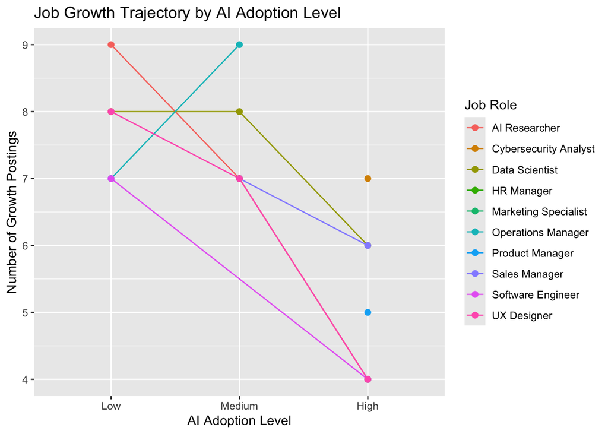

```r
growth_by_adoption <- insights %>%
  filter(!is.na(job_growth_projection), !is.na(ai_adoption_level)) %>%
    count(job_title, ai_adoption_level, job_growth_projection) %>%
    filter(job_growth_projection == "Growth") %>%
    arrange(ai_adoption_level, desc(n)) %>%
    group_by(ai_adoption_level) %>%
    slice_max(n, n = 5) %>%
    ungroup()

  ggplot(growth_by_adoption, aes(x = ai_adoption_level, y = n, color = job_title, group = job_title)) +
    geom_line() +
    geom_point(size = 2) +
    scale_x_discrete(limits = c("Low", "Medium", "High")) +
    labs(
      title = "Job Growth Trajectory by AI Adoption Level",
      x = "AI Adoption Level",
      y = "Number of Growth Postings",
      color = "Job Role"
    )
```

## Limitations:

### The classification of roles such as “Growth” or “Decline” are not very specific measures of the market. The numbers for some sectors may also be skewed as they use more public postings while other sectors are underrepresented as they hire internally.

## Potential Improvements:

### In the future we could gather more datasets surrounding employee’s and companies’ exposure to AI and the skill requirements of different industries to better understand how companies in non-tech sectors utilize AI and people with AI skills differently.

## Research Q4: What countries are leading in AI job growth relative to GDP or population?

## Data / Visualization:

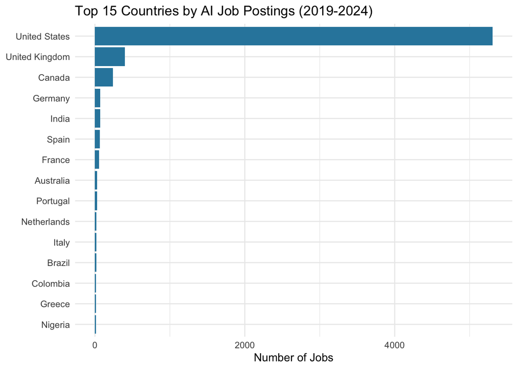

```r
finalData %>%
  slice_max(jobCount, n = 15) %>%
  ggplot(aes(x = reorder(Country, jobCount), y = jobCount)) +
  geom_col(fill = "#2E86AB") +
  coord_flip() +
  labs(
    title = "Top 15 Countries by AI Job Postings (2019-2024)",
    x = NULL,
    y = "Number of Jobs"
  ) +
  theme_minimal()
```

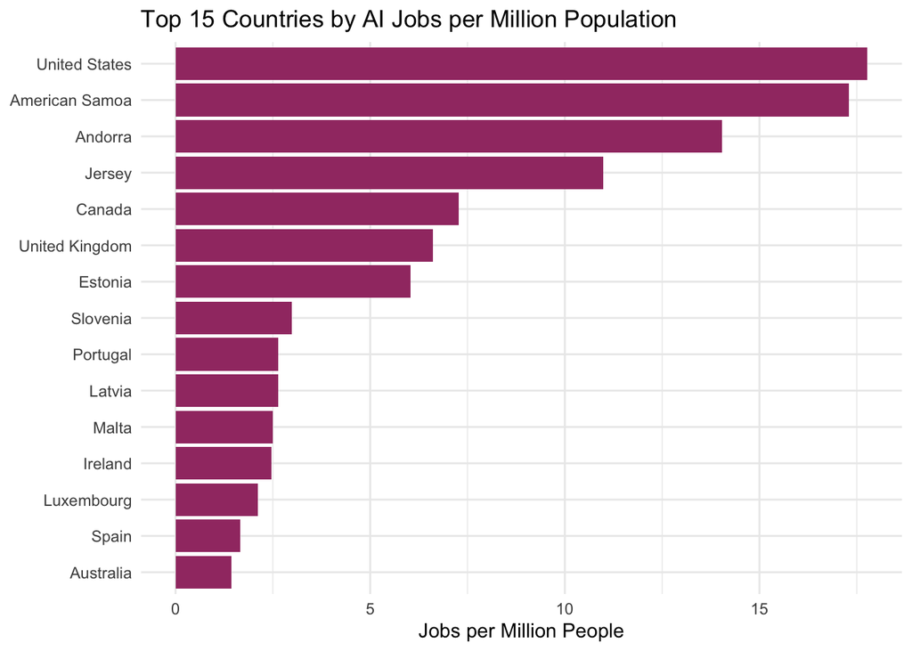

```r
finalData %>%
  slice_max(jobsPerMillion, n = 15) %>%
  ggplot(aes(x = reorder(Country, jobsPerMillion), y = jobsPerMillion)) +
  geom_col(fill = "#A23B72") +
  coord_flip() +
  labs(
    title = "Top 15 Countries by AI Jobs per Million Population",
    x = NULL,
    y = "Jobs per Million People"
  ) +
  theme_minimal()
```

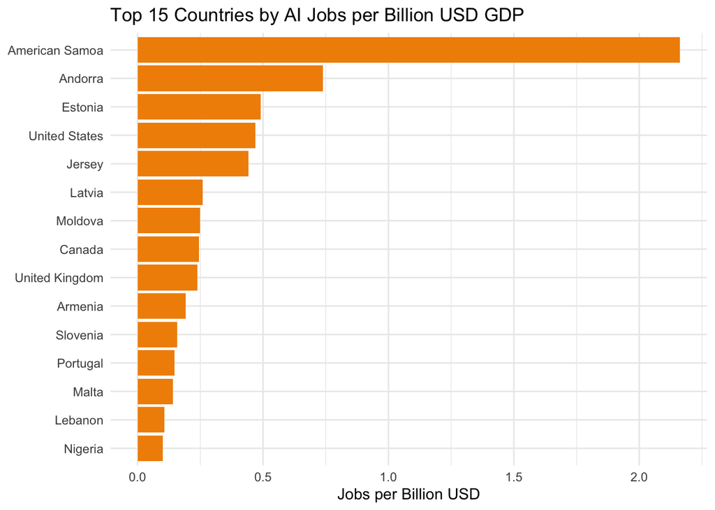

```r
finalData %>%
  filter(jobsPerBillionGdp < Inf) %>%
  slice_max(jobsPerBillionGdp, n = 15) %>%
  ggplot(aes(x = reorder(Country, jobsPerBillionGdp), y = jobsPerBillionGdp)) +
  geom_col(fill = "#F18F01") +
  coord_flip() +
  labs(
    title = "Top 15 Countries by AI Jobs per Billion USD GDP",
    x = NULL,
    y = "Jobs per Billion USD"
  ) +
  theme_minimal()
```

## Summary statistics table

```r
finalData %>%
  arrange(desc(jobCount)) %>%
  select(Country, jobCount, jobsPerMillion, jobsPerBillionGdp) %>%
  mutate(
    jobsPerMillion = round(jobsPerMillion, 1),
    jobsPerBillionGdp = round(jobsPerBillionGdp, 2)
  ) %>%
  head(15)
```

```
## # A tibble: 15 × 4
##    Country        jobCount jobsPerMillion jobsPerBillionGdp
##    <chr>             <int>          <dbl>             <dbl>
##  1 United States      5305           17.8              0.47
##  2 United Kingdom      401            6.6              0.24
##  3 Canada              241            7.3              0.24
##  4 Germany              71            0.9              0.03
##  5 India                70            0.1              0.02
##  6 Spain                67            1.7              0.08
##  7 France               53            0.9              0.03
##  8 Australia            29            1.4              0.05
##  9 Portugal             28            2.6              0.15
## 10 Netherlands          21            1.3              0.04
## 11 Italy                20            0.3              0.01
## 12 Brazil               19            0.1              0.01
## 13 Colombia             14            0.3              0.05
## 14 Greece               13            1.2              0.06
## 15 Nigeria              12            0.1              0.1
```

### Potential Improvements: In the future we could improve the merging by some sort of code instead of country names and add job datasets outside of just English postings. We could also use other metrics to determine why some countries have a higher AI workforce concentration than other countries.

## # 7. Discussion

### These limitations mean we can be confident about broad trends, such as overall salary growth and which major countries lead in AI employment, but less sure about specific numbers or rankings for smaller countries. Future research should track these patterns over longer time periods, analyze which specific AI skills are most valuable, and incorporate data from non- English job markets to get a truly global picture.

## # 8. Summary

### These findings matter for different groups. Workers should develop AI skills to improve career prospects, but should also focus on continuous learning as the field evolves quickly. Companies face intense competition for AI talent and must offer substantial compensation. Policymakers should note that even smaller countries can build AI capacity through focused investment, though large markets maintain scale advantages. AI represents a major workforce transformation across multiple industries. Unlike past technological changes limited to specific sectors, AI’s broad applicability creates both disruption and opportunity across the economy. Our analysis captures this shift as AI moves from experimental technology to an essential business tool. The patterns we identify are not fixed - different industries and countries are adopting AI at different speeds, meaning stakeholders can influence how this transformation unfolds in their contexts. Understanding current trends provides a foundation for workers making career decisions, companies planning hiring strategies, and policymakers designing programs to support workforce adaptation.